# Introduction to the `better` package

## Introduction

The `better` package helps you guesstimate the effect of health nudges, that is, behavioral interventions targeted at health behaviors. With `better` guesstimates, you can make the world a `better` place! In addition to guesstimating effect sizes, `better` also helps you guesstimate sample sizes for properly powered studies on health nudges. Finally, `better` also gives guesstimates of how much money you would save in terms of health care.

To make data-driven guesstimates, `better` uses the [Global Burden of Disease (GBD) dataset](https://www.healthdata.org/gbd/2019), an incredibly rich dataset created and maintained by the [Institute for Health Metrics and Evaluation](https://www.healthdata.org/) at the University of Washington, and property of the University of Washington.

## An example: A diet-related nudge for diabetics

The main purpose of `better` is to help you better guesstimate the effect of health nudges, that is, behavioral interventions targeted at health behaviors.

Imagine you are designing a public health campaign. You are thinking about focusing on diabetics, and you are considering making information about healthy foods more accessible. What effects can you expect from a campaign like that?

This is how we would make a guesstimate with `better`. Let’s load it, and let’s also load `tidyverse`, so we can use pipes and other tidy constructions.

```r
library(better)
library(tidyverse)

nudge("information", behavior = "food") %>%
  disease("diabetes mellitus") %>%
  describe
```

```
#> A behavioral intervention in nudge category "information" and behavior category "food" that targets diabetes mellitus saves 85.2 DALYs per 100,000 people, 95% CI [29.5, 157.3].
```

Note that “DALYs” are *disability-adjusted life years*, a measure of overall disease burden, expressed as the number of years lost due to disease, disability or early death. The output above shows DALYs *saved* by the nudge, that is, the number of years *saved* due to *decreased* disease, disability and death.

As for the code: We basically told `nudge()` what kind of nudge we are envisioning, `"information"`, and what kind of behavior we are targeting: `"food"`-related behavior. We piped the result into `disease()` and told it what disease we are targeting: `"diabetes mellitus"`. Finally, `describe()` simplified the output to a brief description of the guesstimate, which is what you saw.

What if we don’t really know what we want to focus on? We can compare effects:

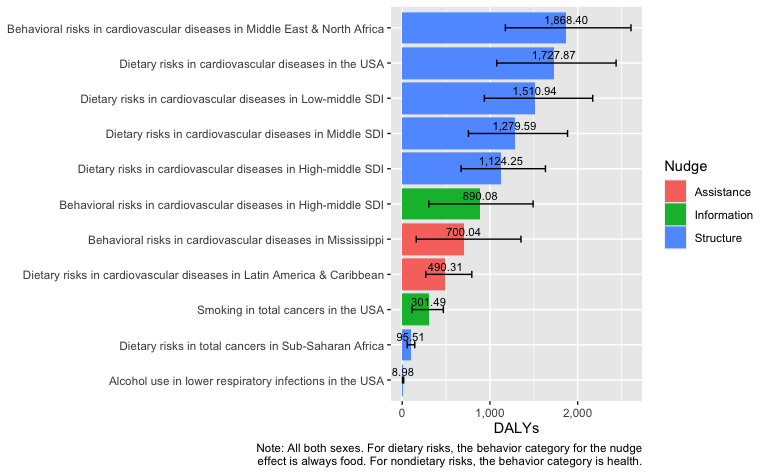

```r
compare_effects() # location = "United States of America"
```

So, we got our guesstimate in terms of DALYs saved. There’s many other measures we can get estimates for. Let’s see how many *years lived with disability* or “YLDs” our nudge would save:

```r
nudge("information", behavior = "food") %>%
  disease("diabetes mellitus", measure = "YLDs") %>%
  describe
```

```
#> A behavioral intervention in nudge category "information" and behavior category "food" that targets diabetes mellitus saves 46.9 YLDs per 100,000 people, 95% CI [14.0, 95.9].
```

The reason why I picked YLDs is because it allows us to guesstimate the cost of healthcare saved by the nudge. We do that as follows, with `cost()`:

```r
nudge("information", behavior = "food") %>%
  disease("diabetes mellitus", measure = "YLDs") %>%
  cost %>%
  describe
```

```
#> The annual health care costs saved because of reducing YLDs per 100,000 people is $499,525; 95% CI [126,528; 1,178,042].
```

Note that cost calculation is still a feature in development: for now it doesn’t yet distinguish between the costs of different diseases. Run `?cost` to read more.

Once we have the cost savings, we can also guesstimate the *net* savings in cost, that is, the savings from reduce healthcare costs minus the cost of the nudge, of running the campaign. We use the `net()` function:

```r
nudge("information", behavior = "food") %>%
  disease("diabetes mellitus", measure = "YLDs") %>%
  cost %>%
  net %>%
  describe
```

```
#> The annual net cost savings, after deducting campaign costs, is $469,852; 95% CI [69,162; 1,176,064].
```

Next, say you are in charge of a campaign at an insurance company with 350,000 members. You can also calculate the net savings for 350,000 members, with the `per()` function:

```r
nudge("information", behavior = "food") %>%
  disease("diabetes mellitus", measure = "YLDs") %>%
  cost %>%
  net %>%
  per(350000) %>%
  describe
```

```
#> Annual net cost of YLDs per 350,000 people saved is $1,644,483; 95% CI [242,066; 4,116,223].
```

Finally, say you are considering running an experiment with your members, to see if your nudge has a positive impact. You can do quick power calculations with `sample_size()`. Here is how to do a power calculation for an experiment that wants to detect an impact on food-related behaviors.

```r
nudge("information", behavior = "food") %>%
  describe
```

```
#> Cohen's d for nudge category "information" and behavior category "food" is 0.44, 95% CI [0.19, 0.70].
```

```r
nudge("information", behavior = "food") %>%
  sample_size
```

```
#>
#>      Two-sample t test power calculation
#>
#>               n = 64.55656
#>               d = -0.44
#>       sig.level = 0.05
#>           power = 0.8
#>     alternative = less
#>
#> NOTE: n is number in *each* group
```

Here is how to do a power calculation for a much more ambitious experiment that wants to detect on impact on saving lives (preventing deaths):

```r
nudge("information", behavior = "food") %>%
  disease("diabetes mellitus", measure = "deaths") %>%
  describe
```

```
#> A behavioral intervention in nudge category "information" and behavior category "food" that targets diabetes mellitus saves 1.90 deaths per 100,000 people, 95% CI [0.71, 3.26].
```

```r
nudge("information", behavior = "food") %>%
  disease("diabetes mellitus", measure = "deaths") %>%
  sample_size
```

```
#> The effect implies a drop from the baseline of 4.83 deaths to 2.93 deaths per 100,000. We translate these proportions into a Cohen's h with pwr::ES.h() for the power calculation.
#>
#>      Difference of proportion power calculation for binomial distribution (arcsine transformation)
#>
#>               h = -0.003065874
#>               n = 1315496
#>       sig.level = 0.05
#>           power = 0.8
#>     alternative = less
#>
#> NOTE: same sample sizes
```

The low number of yearly deaths means you’ll need a huge sample size! Better just look at behavior change!

Alright, that’s a quick overview of what `better` can do for you!

## Complicate things

```r
nudge("information", behavior = "food") %>%
  disease("diabetes mellitus") %>%
  describe
```

```
#> A behavioral intervention in nudge category "information" and behavior category "food" that targets diabetes mellitus saves 85.2 DALYs per 100,000 people, 95% CI [29.5, 157.3].
```

Now, to get the estimate, we called two functions: `nudge()` and `disease()`. That’s because we first guesstimate the effect of the nudge on behavior, and then we guesstimate the effect of behavior on disease (DALYs). You can check out the effect of the nudge on behavior by only calling the first function:

```r
nudge("information")
```

```
#> This is a `better_effect` object. For more details, including terms of use, run `?disease`.
#>   Effect:
#>
#> 0.26 standard deviations, 95% CI [0.09, 0.43]
#>
#> Summary: Cohen's d for nudge category "information" and behavior category
#> "health" is 0.26, 95% CI [0.09, 0.43].
#>
#>   Parameters:
#>
#> rei = behavioral risks, location = Global, behavior = health, nudge =
#> information
#>
#>   Explanation:
#>
#> This statistic comes from a meta-analysis on the effectiveness of nudging.
#> This is the abstract of the original paper: "Over the past decade, choice
#> architecture interventions or socalled nudges have received widespread attention
#> from both researchers and policy makers. Built on insights from the be...
#> [TRUNCATED]
#> ...y making."
#>
#> See:
#> Mertens, S., Herberz, M., Hahnel, U. J. J., & Brosch, T. (2022). The
#> effectiveness of nudging: A meta-analysis of choice architecture interventions
#> across behavioral domains. Proceedings of the National Academy of Sciences,
#> 119(1), e2107346118. https://doi.org/10.1073/pnas.2107346118
#>
#>   Source:
#>
#> Mertens, Herberz, Hahnel, & Brosch (2022). For details, run `?nudge_data`.
```

The philosophy of `better` is to create pipes of guesstimate functions, like `nudge()` and `disease()`, to get a more complicated guesstimate consisting of multiple steps. We can get the full explanation of the guesstimate with `better::explanation()`:

```r
nudge("information") %>%
  disease("cardiovascular diseases") %>%
  explanation
```

```
#> Step 1:
#>
#> Estimate: Cohen's d for nudge category "information" and behavior category
#> "health" is 0.26, 95% CI [0.09, 0.43].
#>
#> This statistic comes from a meta-analysis on the effectiveness of nudging.
#> This is the abstract of the original paper: "Over the past decade, choice
#> architecture interventions or socalled nudges have received widespread attention
#> from both researchers and policy makers. Built on insights from the behavioral
#> sciences, this class of behavioral interventions focuses on the design of
#> choice environments that facilitate personally and socially desirable decisions
#> without restricting people in their freedom of choice. Drawing on more than
#> 200 studies reporting over 440 effect sizes (n = 2,148,439), we present a
#> comprehensive analysis of the effectiveness of choice architecture interventions
#> across techniques, behavioral domains, and contextual study characteristics.
#> Our results show that choice architecture interventions overall promote behavior
#> change with a small to medium effect size of Cohen's d = 0.43 (95% CI [0.38,
#> 0.48]). In addition, we find that the effectiveness of choice architecture
#> interventions varies significantly as a function of technique and domain. Across
#> behavioral domains, interventions that target the organization and structure of
#> choice alternatives (decision structure) consistently outperform interventions
#> that focus on the description of alternatives (decision information) or the
#> reinforcement of behavioral intentions (decision assistance). Food choices
#> are particularly responsive to choice architecture interventions, with effect
#> sizes up to 2.5 times larger than those in other behavioral domains. Overall,
#> choice architecture interventions affect behavior relatively independently
#> of contextual study characteristics such as the geographical location or the
#> target population of the intervention. Our analysis further reveals a moderate
#> publication bias toward positive results in the literature. We end with a
#> discussion of the implications of our findings for theory and behaviorally
#> informed policy making."
#>
#> See:
#> Mertens, S., Herberz, M., Hahnel, U. J. J., & Brosch, T. (2022). The
#> effectiveness of nudging: A meta-analysis of choice architecture interventions
#> across behavioral domains. Proceedings of the National Academy of Sciences,
#> 119(1), e2107346118. https://doi.org/10.1073/pnas.2107346118
#>
#> Step 2:
#>
```

[output cut: 56 more lines]

```
#> risks is 33.8 percent, 95% CI [13.1, 50.1]. We also know that at 15.1%, exposure
#> to behavioral risks costs 2,516 DALYs per 100,000 people due to cardiovascular
#> diseases. That is, we know from the GBD data that in 2019, globally, the
#> estimated cost of cardiovascular diseases due to behavioral risks, for both men
#> and women of all ages (age-standardized), was 2,516 DALYs per 100,000 people;
#> 95% CI [2,242; 2,860]. The last step is to take 33.8 percent, 95% CI [13.1,
#> 50.1], of 2,516 DALYs; 95% CI [2,242; 2,860], and to combine both confidence
#> intervals. That gives us the estimate that the nudge saves 852 DALYs per 100,000
#> people; 95% CI [293; 1,432].
#>
#> See:
#> Global Burden of Disease Collaborative Network. Global Burden of
#> Disease Study 2019 (GBD 2019) Results. Seattle, United States:
#> Institute for Health Metrics and Evaluation (IHME), 2020. Available from
#> https://vizhub.healthdata.org/gbd-results/
```

This output also shows you that there was an intermediate step in the calculation.

Let’s see what happens if we would shift the focus of our intervention to diabetes mellitus. To simplify the output, I use `better::effect_only`. It prints only the effect, leaving out the parameters and explanation.

```r
nudge("information") %>%
  disease("diabetes mellitus") %>%
  effect_only
```

```
#> This is a `better_effect` object. For more details, including terms of use, run `?disease`.
#> 119.6 DALYs per 100,000 people, 95% CI [36.8, 220.3]
```

What if we tried a structural nudge?

```r
nudge("structure") %>%
  disease("diabetes mellitus") %>%
  effect_only
```

```
#> This is a `better_effect` object. For more details, including terms of use, run `?disease`.
#> 180 DALYs per 100,000 people, 95% CI [104, 272]
```

What if we wanted to see the impact on deaths?

```r
nudge("structure") %>%
  disease("diabetes mellitus", measure = "deaths") %>%
  effect_only
```

```
#> This is a `better_effect` object. For more details, including terms of use, run `?disease`.
#> 4.06 deaths per 100,000 people, 95% CI [2.52, 5.65]
```

You can also get quick power calculations. Say you want to run an experiment, testing the information nudge, with two conditions: a treatment, and a control. You hypothesize the nudge will decrease risky behaviors. How many observations do you need in each condition?

```r
nudge("information") %>%
  sample_size
```

```
#>
#>      Two-sample t test power calculation
#>
#>               n = 183.596
#>               d = -0.26
#>       sig.level = 0.05
#>           power = 0.8
#>     alternative = less
#>
#> NOTE: n is number in *each* group
```

So, you need about 184 observations per condition. You may recognize this kind of output. It’s the output of `pwr.t.test()` from the `pwr` package, because `sample_size()` wraps that function.

What if we don’t really know what we want to focus on? We can compare effects:

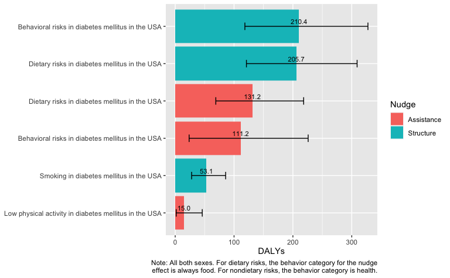

```r
compare_effects(location = "United States of America", cause = "diabetes mellitus")
```

You can also run it without any constraints:

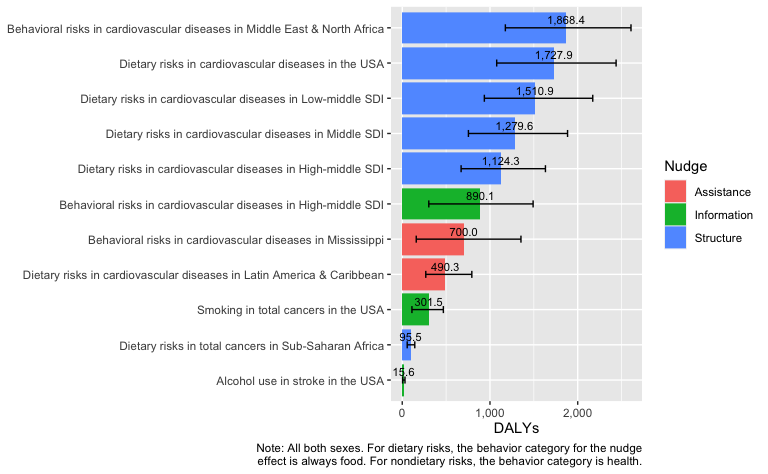

```r
compare_effects()
```

## Input your own effect size

Imagine you are still designing that public health campaign, on preventing cardiovascular diseases. But suppose you know the effect of your intervention on behavior (or you know the effect you want, etc.). More specifically, you have a Cohen’s *d*. Then, `better::behavior_d` allows you to create an effect out of that, in the following way:

```r
behavior_d(.56) %>%
  disease("cardiovascular diseases") %>%
  effect_only
```

```
#> This is a `better_effect` object. For more details, including terms of use, run `?disease`.
#> 1,508 DALYs per 100,000 people; 95% CI [NA; NA]
```

Rather than manually entering one effect size, you may also want to create your own `better`-style functions. Here’s an example:

```r
d_categorical <- function(size) {
  if (size == "small") {
    d <- .2
  } else if (size == "medium") {
    d <- .5
  } else if (size == "large") {
    d <- .8
  }
  behavior_d(d, d, d)
}
d_categorical("large")
```

```
#> This is a `better_effect` object. For more details, including terms of use, run `?disease`.
#>   Effect:
#>
#> 0.80 standard deviations, 95% CI [0.80, 0.80]
#>
#> Summary: NA
#>
#>   Parameters:
#>
#> rei = behavioral risks
#>
#>   Explanation:
#>
#> 0.80 standard deviations, 95% CI [0.80, 0.80]
#>
#> This is a manually inserted Cohen's d.
#>
#>   Source:
```

```r
d_categorical("large") %>%
  disease("cardiovascular diseases") %>%
  effect_only
```

```
#> This is a `better_effect` object. For more details, including terms of use, run `?disease`.
#> 1,849 DALYs per 100,000 people; 95% CI [1,648; 2,102]
```

You can also enter a percentage difference (decrease in the risky behavior) with `better::behavior_pct`. Say you know it decreases risky behavior by 11.4%:

```r
behavior_pct(11.4) %>%
  disease("cardiovascular diseases") %>%
  effect_only
```

```
#> This is a `better_effect` object. For more details, including terms of use, run `?disease`.
#> 28,681 DALYs per 100,000 people; 95% CI [NA; NA]
```

If you start from Cohen’s *d*, the calculation is in three steps, because Cohen’s *d* needs to be translated in a percentage difference:

```r
behavior_d(.56) %>%
  behavior_d_to_pct %>%
  behavior_pct_to_disease("cardiovascular diseases") %>%
  effect_only
```

```
#> This is a `better_effect` object. For more details, including terms of use, run `?disease`.
#> 2,516 DALYs per 100,000 people; 95% CI [NA; NA]
```

In contrast, if you start from a percentage difference, it’s only two steps:

```r
behavior_pct(11.4) %>%
  behavior_pct_to_disease("cardiovascular diseases") %>%
  effect_only
```

```
#> This is a `better_effect` object. For more details, including terms of use, run `?disease`.
#> 28,681 DALYs per 100,000 people; 95% CI [NA; NA]
```

## Breaking things up

Earlier on we looked at this very simple example of an impact guesstimate:

```r
nudge("information") %>%
  disease("cardiovascular diseases") %>%
  effect_only
```

```
#> This is a `better_effect` object. For more details, including terms of use, run `?disease`.
#> 852 DALYs per 100,000 people; 95% CI [293; 1,432]
```

Here is the full reasoning behind it:

First, we look up the effect of an information nudge on health behavior. Note that, rather than `nudge()`, I’m using `nudge_to_behavior_d()` here. It’s an alias with different defaults. But it’s more explicit, and that’s what we want now.

```r
nudge_to_behavior_d(nudge = "information", behavior = "health") %>%
  effect_only
```

```
#> This is a `better_effect` object. For more details, including terms of use, run `?disease`.
#> 0.26 standard deviations, 95% CI [0.09, 0.43]
```

This gives us a Cohen’s *d*, a standardized effect size for the health information nudge, namely, *d* = 0.26.

Second, we translate Cohen’s *d* into an odds ratio.

```r
step2 <- nudge_to_behavior_d(nudge = "information", behavior = "health") %>%
  d_to_OR %>%
  effect_only
```

```
#> This is a `better_effect` object. For more details, including terms of use, run `?disease`.
#> 1.60, 95% CI [1.18, 2.18]
```

Let’s look at the explanation:

```r
step2 %>%
  explanation(full = FALSE)
```

```
#> Following the method of Hasselblad and Hedges (1995), we convert Cohen's d into
#> an odds ratio (OR) with the following formula: exp(d*pi/sqrt(3)). Since the log
#> odds ratio (LOR) is d*pi/sqrt(3), the odds ratio (OR) is exp(d*pi/sqrt(3)).
#>
#> See:
#> Hasselblad, V., & Hedges, L. V. (1995). Meta-analysis of screening
#> and diagnostic tests. Psychological Bulletin, 117(1), 167-178.
#> https://doi.org/10.1037/0033-2909.117.1.167
```

Third, we convert the odds ratio into a percentage difference, because that’s how we can link it to the Global Burden of Disease dataset.

```r
step3 <- nudge_to_behavior_d(nudge = "information", behavior = "health") %>%
  d_to_OR %>%
  behavior_OR_to_pct %>%
  effect_only
```

```
#> This is a `better_effect` object. For more details, including terms of use, run `?disease`.
#> 33.8 percent, 95% CI [13.1, 50.1]
```

Let’s look at the explanation:

```r
step3 %>%
  explanation(full = FALSE)
```

```
#> Note: If the estimate has a minus sign, it indicates an increase in behavioral
#> risks.
#>
#> The odds ratio is 1.60, 95% CI [1.18, 2.18]. Because the effect represents a
#> decrease in the occurrence of the behavior, we take the inverse of this OR,
#> wich gives: 0.62, 95% CI [0.46, 0.85]. To convert the OR into the percentage
#> decrease in behavioral risk exposure, we make use of the following formula: OR
#> = Ot/Oc, where Ot refers to the odds of the behavior occurring given the nudge
#> ("treatment"), and Oc refers to the odds without nudge ("control"). We also
#> know that Ot = Pt/(1 - Pt) and Oc = Pc/(1 - Pc), with Pt and Pc referring to
#> the probabilities of the behavior occurring given either the nudge ("treatment")
#> or no nudge ("control"). From these formulas, one can derive that Pt = OR*Pc/(1
#> + OR*Pc - Pc). So, to calculate Pt we need not only OR but also Pc. We obtain
#> Pc from data on exposure to behavioral risks from the Global Burden of Disease
#> study (GBD). The GBD codebook defines the Summary Exposure Value (SEV) as a
#> measure of a population's exposure to a risk factor that takes into account the
#> extent of exposure by risk level and the severity of that risk's contribution
#> to disease burden. SEV takes the value zero when no excess risk for a population
#> exists and the value one when the population is at the highest level of risk.
#> They report SEV on a scale from 0% to 100% to emphasize that it is risk-weighted
#> prevalence. So, exposure is here a proportion. So we can get Pc from the GBD
#> dataset. According to this dataset, in 2019, globally, the estimated exposure
#> to behavioral risks, for both men and women of all ages (age-standardized), was
#> 15.1 percent, 95% CI [13.0, 17.4]. Given the formula mentioned higher, Pt is
#> then 0.10, 95% CI [0.08, 0.13]. Finally, the percentage difference is simply (Pc
#> - Pt)/Pc.
#>
#> See:
#> Global Burden of Disease Collaborative Network. Global Burden of
#> Disease Study 2019 (GBD 2019) Results. Seattle, United States:
#> Institute for Health Metrics and Evaluation (IHME), 2020. Available from
#> https://vizhub.healthdata.org/gbd-results/
```

Finally, we can get our guesstimate of the effect:

```r
step4 <- nudge_to_behavior_d(nudge = "information", behavior = "health") %>%
  d_to_OR %>%
  behavior_OR_to_pct %>%
  behavior_pct_to_disease("cardiovascular diseases") %>%
  effect_only
```

```
#> This is a `better_effect` object. For more details, including terms of use, run `?disease`.
#> 852 DALYs per 100,000 people; 95% CI [293; 1,432]
```

Let’s look at the explanation:

```r
step4 %>%
  explanation(full = FALSE)
```

```
#> We previously estimated that the percentage decrease in exposure to behavioral
#> risks is 33.8 percent, 95% CI [13.1, 50.1]. We also know that at 15.1%, exposure
#> to behavioral risks costs 2,516 DALYs per 100,000 people due to cardiovascular
#> diseases. That is, we know from the GBD data that in 2019, globally, the
#> estimated cost of cardiovascular diseases due to behavioral risks, for both men
#> and women of all ages (age-standardized), was 2,516 DALYs per 100,000 people;
#> 95% CI [2,242; 2,860]. The last step is to take 33.8 percent, 95% CI [13.1,
#> 50.1], of 2,516 DALYs; 95% CI [2,242; 2,860], and to combine both confidence
#> intervals. That gives us the estimate that the nudge saves 852 DALYs per 100,000
#> people; 95% CI [293; 1,432].
#>
#> See:
#> Global Burden of Disease Collaborative Network. Global Burden of
#> Disease Study 2019 (GBD 2019) Results. Seattle, United States:
#> Institute for Health Metrics and Evaluation (IHME), 2020. Available from
#> https://vizhub.healthdata.org/gbd-results/
```

Note that this is based on the following statistic:

```r
gbd_describe(cause = "cardiovascular diseases")
```

```
#> In 2019, globally, the estimated cost of cardiovascular diseases, for both men
#> and women of all ages (age-standardized), was 4,864 DALYs per 100,000 people;
#> 95% CI [4,549; 5,164]. Note that DALYs refers to disability adjusted life years.
```

To organize:

```r
gbd_cb <- gbd_codebook()
nudge_cb <- nudge_codebook()
nudge_cb$nudge
```

```
#> # A tibble: 3 × 2
#>   nudge       explain
#>   <chr>       <chr>
#> 1 information intervention that focuses on the description of alternatives (dec…
#> 2 structure   intervention that targets the organization and structure of choic…
#> 3 assistance  intervention that reinforces behavioral intentions (decision assi…
```

```r
nudge_cb$behavior
```

```
#> # A tibble: 6 × 1
#>   behavior
#>   <chr>
#> 1 health
#> 2 food
#> 3 environment
#> 4 finance
#> 5 pro-social
#> 6 other
```

## Using different guesstimate methods

To convert the Cohen’s *d* into a percentage decrease, by default, `disease()` uses the method from Hasselblad and Hedges (1995) to convert *d* into an odds ratio:

```r
nudge("information") %>%
  disease("cardiovascular diseases") %>%
  effect_only
```

```
#> This is a `better_effect` object. For more details, including terms of use, run `?disease`.
#> 852 DALYs per 100,000 people; 95% CI [293; 1,432]
```

```r
# same:
nudge("information") %>%
  disease("cardiovascular diseases", method = "Hasselblad and Hedges") %>%
  effect_only
```

```
#> This is a `better_effect` object. For more details, including terms of use, run `?disease`.
#> 852 DALYs per 100,000 people; 95% CI [293; 1,432]
```

We can also use an alternative method, based on the fact that Cohen’s *d* is a difference *in standard deviations*.

```r
nudge("information") %>%
  disease("cardiovascular diseases", method = "standard deviations") %>%
  effect_only
```

```
#> This is a `better_effect` object. For more details, including terms of use, run `?disease`.
#> 1,552 DALYs per 100,000 people; 95% CI [479; 2,860]
```

Let’s walk through what happens behind the scene when `disease(method = "standard deviations)` does it’s magic. The input is of course again a Cohen’s *d*:

```r
nudge("information") %>%
  effect_only
```

```
#> This is a `better_effect` object. For more details, including terms of use, run `?disease`.
#> 0.26 standard deviations, 95% CI [0.09, 0.43]
```

Then, as an intermediate step, it translates Cohen’s *d* into a percentage difference, because that’s how we can link it to the Global Burden of Disease dataset.

```r
eff <- nudge("information") %>%
  behavior_d_to_pct %>%
  effect_only
```

```
#> This is a `better_effect` object. For more details, including terms of use, run `?disease`.
#> 61.7 percent, 95% CI [21.4, 100.0]
```

This gives us a decrease of 61.7 percent. Let’s look at the explanation:

```r
eff %>%
  explanation(full = FALSE)
```

```
#> Note: If the estimate has a minus sign, it indicates an increase in behavioral
#> risks.
#>
#> We derive the estimate from the Cohen's d for nudge category "information"
#> and behavior category "health", which is 0.26, 95% CI [0.09, 0.43]. Now, to
#> calculate the percentage decrease, we make use of data on exposure to behavioral
#> risks from the Global Burden of Disease study (GBD). The GBD codebook defines
#> the Summary Exposure Value (SEV) as a measure of a population's exposure to a
#> risk factor that takes into account the extent of exposure by risk level and
#> the severity of that risk's contribution to disease burden. SEV takes the value
#> zero when no excess risk for a population exists and the value one when the
#> population is at the highest level of risk. They report SEV on a scale from 0%
#> to 100% to emphasize that it is risk-weighted prevalence. So, exposure is here a
#> proportion. Since exposure is not a numeric variable, we can't use a traditional
#> Cohen's d. However, Cohen's d essentially describes the effect in terms of
#> standard deviations. For proportions, the standard deviation equals the square
#> root of p*(1-p), where p is the proportion. (For computational simplicity,
#> we assume Cohen's d is calculated using the standard deviation of the control
#> group, without a behavioral nudge, rather than the pooled standard deviation.)
#> We get the baseline proportion from the GBD dataset. According to this dataset,
#> in 2019, globally, the estimated exposure to behavioral risks, for both men and
#> women of all ages (age-standardized), was 15.1 percent, 95% CI [13.0, 17.4].
#> The standard deviation is then sqrt(p*(1-p)), that is, 35.8 percentage points.
#> (Note that we chose not to add an extra confidence interval here for the error
#> on the baseline proportion, because `behavior_pct_to_disease()` already adds a
#> confidence interval based on GBD data error.) The percentage point difference
#> (decrease) is then simply the Cohen's d and its confidence interval multiplied
#> by this standard deviation. That tells us the percentage point decrease in
#> exposure to behavioral risks is 9.31 percentage points, 95% CI [3.22, 15.39].
#> So, exposure to behavioral risks drops from 15.09 percent without nudge, to 5.78
#> percent, 95% CI [0.00, 11.87] with nudge. Note: If the jump from Cohen's d to
#> proportions is difficult to follow, think of proportion data, like the Summary
#> Exposure Value data, as numeric data with two values: 0 and 1. You can calculate
#> the mean of that (bivalent) numeric variable as usual: you would find it equals
#> the proportion. You can also calculate the standard deviation as usual: you
#> would find it equals sqrt(p*(1-p)). Since we have two groups - a control group
#> and a nudged group - you can also calculate Cohen's d as usual.
#>
#> The last step is to translate this percentage point decrease into a percentage
#> decrease. Now, a percentage decrease is just the percentage points decrease
#> divided by the baseline proportion, that is, 9.31 percentage points, 95% CI
#> [3.22, 15.39], divided by 15.09. This tells us the percentage decrease is 61.7
#> percent, 95% CI [21.4, 100.0].
#>
#> See:
#> Global Burden of Disease Collaborative Network. Global Burden of
#> Disease Study 2019 (GBD 2019) Results. Seattle, United States:
#> Institute for Health Metrics and Evaluation (IHME), 2020. Available from
#> https://vizhub.healthdata.org/gbd-results/
```

The last step is the same. We can get our guesstimate of the effect with `behavior_pct_to_disease()`:

```r
nudge_to_behavior_d(nudge = "information", behavior = "health") %>%
  behavior_d_to_pct %>%
  behavior_pct_to_disease("cardiovascular diseases") %>%
  effect_only
```

```
#> This is a `better_effect` object. For more details, including terms of use, run `?disease`.
#> 1,552 DALYs per 100,000 people; 95% CI [479; 2,860]
```

## Effect of nudges

Get the effect size for behavioral interventions aka *nudges* with `better::nudge_to_behavior_d`. This returns an object of the `better_effect` class. It’s basically a list containing the effect size, the confidence interval, and some other metadata. It’s printed in a useful way.

```r
eff <- nudge_to_behavior_d()
eff
```

```
#> This is a `better_effect` object. For more details, including terms of use, run `?disease`.
#>   Effect:
#>
#> 0.43 standard deviations, 95% CI [0.38, 0.48]
#>
#> Summary: Cohen's d for nudge category "all" and behavior category "all" is 0.43,
#> 95% CI [0.38, 0.48].
#>
#>   Parameters:
#>
#> rei = behavioral risks, location = Global, behavior = all, nudge = all
#>
#>   Explanation:
#>
#> This statistic comes from a meta-analysis on the effectiveness of nudging.
#> This is the abstract of the original paper: "Over the past decade, choice
#> architecture interventions or socalled nudges have received widespread attention
#> from both researchers and policy makers. Built on insights from the be...
#> [TRUNCATED]
#> ...y making."
#>
#> See:
#> Mertens, S., Herberz, M., Hahnel, U. J. J., & Brosch, T. (2022). The
#> effectiveness of nudging: A meta-analysis of choice architecture interventions
#> across behavioral domains. Proceedings of the National Academy of Sciences,
#> 119(1), e2107346118. https://doi.org/10.1073/pnas.2107346118
#>
#>   Source:
#>
#> Mertens, Herberz, Hahnel, & Brosch (2022). For details, run `?nudge_data`.
```

```r
class(eff)
```

```
#> [1] "better_effect" "list"
```

```r
str(eff)
```

```
#> List of 13
#>  $ value    : num 0.43
#>  $ lower    : num 0.38
#>  $ upper    : num 0.48
#>  $ stat     : chr "Cohen's d for nudge category \"all\" and behavior category \"all\""
#>  $ unit     : chr "standard deviations"
#>  $ describe : chr "Cohen's d for nudge category \"all\" and behavior category \"all\" is 0.43, 95% CI [0.38, 0.48]."
#>  $ facts    :List of 1
#>   ..$ : chr "Cohen's d for nudge category \"all\" and behavior category \"all\" is 0.43, 95% CI [0.38, 0.48] (Mertens, Herbe"| __truncated__
#>  $ explain  : chr "This statistic comes from a meta-analysis on the effectiveness of nudging. This is the abstract of the original"| __truncated__
#>  $ reference: chr "Mertens, S., Herberz, M., Hahnel, U. J. J., & Brosch, T. (2022). The effectiveness of nudging: A meta-analysis "| __truncated__
#>  $ source   : chr "Mertens, Herberz, Hahnel, & Brosch (2022). For details, run `?nudge_data`."
#>  $ terms    : logi NA
#>  $ call     : chr "nudge_to_behavior_d(), with default arguments: nudge = all, behavior = all"
#>  $ params   :List of 4
#>   ..$ rei     : chr "behavioral risks"
#>   ..$ location: chr "Global"
#>   ..$ behavior: chr "all"
#>   ..$ nudge   : chr "all"
#>  - attr(*, "class")= chr [1:2] "better_effect" "list"
```

```r
eff$value
```

```
#> [1] 0.43
```

Get the full explanation with `better::explanation`.

```r
eff %>%
  explanation
```

```
#> This statistic comes from a meta-analysis on the effectiveness of nudging.
#> This is the abstract of the original paper: "Over the past decade, choice
#> architecture interventions or socalled nudges have received widespread attention
#> from both researchers and policy makers. Built on insights from the behavioral
#> sciences, this class of behavioral interventions focuses on the design of
#> choice environments that facilitate personally and socially desirable decisions
#> without restricting people in their freedom of choice. Drawing on more than
#> 200 studies reporting over 440 effect sizes (n = 2,148,439), we present a
#> comprehensive analysis of the effectiveness of choice architecture interventions
#> across techniques, behavioral domains, and contextual study characteristics.
#> Our results show that choice architecture interventions overall promote behavior
#> change with a small to medium effect size of Cohen's d = 0.43 (95% CI [0.38,
#> 0.48]). In addition, we find that the effectiveness of choice architecture
#> interventions varies significantly as a function of technique and domain. Across
#> behavioral domains, interventions that target the organization and structure of
#> choice alternatives (decision structure) consistently outperform interventions
#> that focus on the description of alternatives (decision information) or the
#> reinforcement of behavioral intentions (decision assistance). Food choices
#> are particularly responsive to choice architecture interventions, with effect
#> sizes up to 2.5 times larger than those in other behavioral domains. Overall,
#> choice architecture interventions affect behavior relatively independently
#> of contextual study characteristics such as the geographical location or the
#> target population of the intervention. Our analysis further reveals a moderate
#> publication bias toward positive results in the literature. We end with a
#> discussion of the implications of our findings for theory and behaviorally
#> informed policy making."
#>
#> See:
#> Mertens, S., Herberz, M., Hahnel, U. J. J., & Brosch, T. (2022). The
#> effectiveness of nudging: A meta-analysis of choice architecture interventions
#> across behavioral domains. Proceedings of the National Academy of Sciences,
#> 119(1), e2107346118. https://doi.org/10.1073/pnas.2107346118
```

The estimate above averaged over all categories of behaviors and nudges. Let’s now look at the impact for specific categories of behaviors and nudges:

```r
nudge_to_behavior_d(behavior = "health")
```

```
#> This is a `better_effect` object. For more details, including terms of use, run `?disease`.
#>   Effect:
#>
#> 0.34 standard deviations, 95% CI [0.25, 0.43]
#>
#> Summary: Cohen's d for nudge category "all" and behavior category "health" is
#> 0.34, 95% CI [0.25, 0.43].
#>
#>   Parameters:
#>
#> rei = behavioral risks, location = Global, behavior = health, nudge = all
#>
#>   Explanation:
#>
#> This statistic comes from a meta-analysis on the effectiveness of nudging.
#> This is the abstract of the original paper: "Over the past decade, choice
#> architecture interventions or socalled nudges have received widespread attention
#> from both researchers and policy makers. Built on insights from the be...
#> [TRUNCATED]
#> ...y making."
#>
#> See:
#> Mertens, S., Herberz, M., Hahnel, U. J. J., & Brosch, T. (2022). The
#> effectiveness of nudging: A meta-analysis of choice architecture interventions
#> across behavioral domains. Proceedings of the National Academy of Sciences,
#> 119(1), e2107346118. https://doi.org/10.1073/pnas.2107346118
#>
#>   Source:
#>
#> Mertens, Herberz, Hahnel, & Brosch (2022). For details, run `?nudge_data`.
```

```r
nudge_to_behavior_d(behavior = "food")
```

```
#> This is a `better_effect` object. For more details, including terms of use, run `?disease`.
#>   Effect:
#>
#> 0.65 standard deviations, 95% CI [0.47, 0.83]
#>
#> Summary: Cohen's d for nudge category "all" and behavior category "food" is
#> 0.65, 95% CI [0.47, 0.83].
#>
#>   Parameters:
#>
#> rei = dietary risks, location = Global, behavior = food, nudge = all
#>
#>   Explanation:
#>
#> This statistic comes from a meta-analysis on the effectiveness of nudging.
#> This is the abstract of the original paper: "Over the past decade, choice
#> architecture interventions or socalled nudges have received widespread attention
#> from both researchers and policy makers. Built on insights from the be...
#> [TRUNCATED]
#> ...y making."
#>
#> See:
#> Mertens, S., Herberz, M., Hahnel, U. J. J., & Brosch, T. (2022). The
#> effectiveness of nudging: A meta-analysis of choice architecture interventions
#> across behavioral domains. Proceedings of the National Academy of Sciences,
#> 119(1), e2107346118. https://doi.org/10.1073/pnas.2107346118
#>
#>   Source:
#>
#> Mertens, Herberz, Hahnel, & Brosch (2022). For details, run `?nudge_data`.
```

```r
nudge_to_behavior_d(nudge = "assistance")
```

```
#> This is a `better_effect` object. For more details, including terms of use, run `?disease`.
#>   Effect:
#>
#> 0.28 standard deviations, 95% CI [0.21, 0.35]
#>
#> Summary: Cohen's d for nudge category "assistance" and behavior category "all"
#> is 0.28, 95% CI [0.21, 0.35].
#>
#>   Parameters:
#>
#> rei = behavioral risks, location = Global, behavior = all, nudge = assistance
#>
#>   Explanation:
#>
#> This statistic comes from a meta-analysis on the effectiveness of nudging.
#> This is the abstract of the original paper: "Over the past decade, choice
#> architecture interventions or socalled nudges have received widespread attention
#> from both researchers and policy makers. Built on insights from the be...
#> [TRUNCATED]
#> ...y making."
#>
#> See:
#> Mertens, S., Herberz, M., Hahnel, U. J. J., & Brosch, T. (2022). The
#> effectiveness of nudging: A meta-analysis of choice architecture interventions
#> across behavioral domains. Proceedings of the National Academy of Sciences,
#> 119(1), e2107346118. https://doi.org/10.1073/pnas.2107346118
#>
#>   Source:
#>
#> Mertens, Herberz, Hahnel, & Brosch (2022). For details, run `?nudge_data`.
```

```r
nudge_to_behavior_d(nudge = "structure")
```

```
#> This is a `better_effect` object. For more details, including terms of use, run `?disease`.
#>   Effect:
#>
#> 0.54 standard deviations, 95% CI [0.46, 0.62]
#>
#> Summary: Cohen's d for nudge category "structure" and behavior category "all" is
#> 0.54, 95% CI [0.46, 0.62].
#>
#>   Parameters:
#>
#> rei = behavioral risks, location = Global, behavior = all, nudge = structure
#>
#>   Explanation:
#>
#> This statistic comes from a meta-analysis on the effectiveness of nudging.
#> This is the abstract of the original paper: "Over the past decade, choice
#> architecture interventions or socalled nudges have received widespread attention
#> from both researchers and policy makers. Built on insights from the be...
#> [TRUNCATED]
#> ...y making."
#>
#> See:
#> Mertens, S., Herberz, M., Hahnel, U. J. J., & Brosch, T. (2022). The
#> effectiveness of nudging: A meta-analysis of choice architecture interventions
#> across behavioral domains. Proceedings of the National Academy of Sciences,
#> 119(1), e2107346118. https://doi.org/10.1073/pnas.2107346118
#>
#>   Source:
#>
#> Mertens, Herberz, Hahnel, & Brosch (2022). For details, run `?nudge_data`.
```

```r
nudge_to_behavior_d(behavior = "food", nudge = "structure")
```

```
#> This is a `better_effect` object. For more details, including terms of use, run `?disease`.
#>   Effect:
#>
#> 0.78 standard deviations, 95% CI [0.54, 1.01]
#>
#> Summary: Cohen's d for nudge category "structure" and behavior category "food"
#> is 0.78, 95% CI [0.54, 1.01].
#>
#>   Parameters:
#>
#> rei = dietary risks, location = Global, behavior = food, nudge = structure
#>
#>   Explanation:
#>
#> This statistic comes from a meta-analysis on the effectiveness of nudging.
#> This is the abstract of the original paper: "Over the past decade, choice
#> architecture interventions or socalled nudges have received widespread attention
#> from both researchers and policy makers. Built on insights from the be...
#> [TRUNCATED]
#> ...y making."
#>
#> See:
#> Mertens, S., Herberz, M., Hahnel, U. J. J., & Brosch, T. (2022). The
#> effectiveness of nudging: A meta-analysis of choice architecture interventions
#> across behavioral domains. Proceedings of the National Academy of Sciences,
#> 119(1), e2107346118. https://doi.org/10.1073/pnas.2107346118
#>
#>   Source:
#>
#> Mertens, Herberz, Hahnel, & Brosch (2022). For details, run `?nudge_data`.
```

```r
nudge_to_behavior_d(behavior = "health", nudge = "information")
```

```
#> This is a `better_effect` object. For more details, including terms of use, run `?disease`.
#>   Effect:
#>
#> 0.26 standard deviations, 95% CI [0.09, 0.43]
#>
#> Summary: Cohen's d for nudge category "information" and behavior category
#> "health" is 0.26, 95% CI [0.09, 0.43].
#>
#>   Parameters:
#>
#> rei = behavioral risks, location = Global, behavior = health, nudge =
#> information
#>
#>   Explanation:
#>
#> This statistic comes from a meta-analysis on the effectiveness of nudging.
#> This is the abstract of the original paper: "Over the past decade, choice
#> architecture interventions or socalled nudges have received widespread attention
#> from both researchers and policy makers. Built on insights from the be...
#> [TRUNCATED]
#> ...y making."
#>
#> See:
#> Mertens, S., Herberz, M., Hahnel, U. J. J., & Brosch, T. (2022). The
#> effectiveness of nudging: A meta-analysis of choice architecture interventions
#> across behavioral domains. Proceedings of the National Academy of Sciences,
#> 119(1), e2107346118. https://doi.org/10.1073/pnas.2107346118
#>
#>   Source:
#>
#> Mertens, Herberz, Hahnel, & Brosch (2022). For details, run `?nudge_data`.
```

You can also access the dataset of Cohen’s *d*’s.

```r
nudge_data()
```

```
#> # A tibble: 12 × 5
#>    behavior nudge           d   low  high
#>    <chr>    <chr>       <dbl> <dbl> <dbl>
#>  1 all      all          0.43  0.38  0.48
#>  2 health   all          0.34  0.25  0.43
#>  3 food     all          0.65  0.47  0.83
#>  4 all      information  0.34  0.27  0.42
#>  5 all      structure    0.54  0.46  0.62
#>  6 all      assistance   0.28  0.21  0.35
#>  7 health   information  0.26  0.09  0.43
#>  8 health   structure    0.44  0.29  0.59
#>  9 health   assistance   0.2   0.05  0.35
#> 10 food     information  0.44  0.19  0.7
#> 11 food     structure    0.78  0.54  1.01
#> 12 food     assistance   0.43  0.28  0.59
#> Source: Mertens, Herberz, Hahnel & Brosch (2022)
```

Proportions

```r
nudge_to_behavior_d(behavior = "health", nudge = "information") %>%
  print %>%
  behavior_d_to_pct(cause = "cardiovascular diseases")
```

```
#> This is a `better_effect` object. For more details, including terms of use, run `?disease`.
#>   Effect:
#>
#> 0.26 standard deviations, 95% CI [0.09, 0.43]
#>
#> Summary: Cohen's d for nudge category "information" and behavior category
#> "health" is 0.26, 95% CI [0.09, 0.43].
#>
#>   Parameters:
#>
#> rei = behavioral risks, location = Global, behavior = health, nudge =
#> information
#>
#>   Explanation:
#>
#> This statistic comes from a meta-analysis on the effectiveness of nudging.
#> This is the abstract of the original paper: "Over the past decade, choice
#> architecture interventions or socalled nudges have received widespread attention
#> from both researchers and policy makers. Built on insights from the be...
#> [TRUNCATED]
#> ...y making."
#>
#> See:
#> Mertens, S., Herberz, M., Hahnel, U. J. J., & Brosch, T. (2022). The
#> effectiveness of nudging: A meta-analysis of choice architecture interventions
#> across behavioral domains. Proceedings of the National Academy of Sciences,
#> 119(1), e2107346118. https://doi.org/10.1073/pnas.2107346118
#>
#>   Source:
#>
#> Mertens, Herberz, Hahnel, & Brosch (2022). For details, run `?nudge_data`.
#> This is a `better_effect` object. For more details, including terms of use, run `?disease`.
#>   Effect:
#>
#> 61.7 percent, 95% CI [21.4, 100.0]
#>
#> Summary: The percentage decrease in behavioral risks exposure is 61.7 percent,
#> 95% CI [21.4, 100.0].
#>
#>   Parameters:
```

[output cut: 10 more lines]

```
#> and behavior category "health", which is 0.26, 95% CI [0.09, 0.43]. Now, to
#> calculate the percentage decrease, we make use of data on expo... [TRUNCATED]
#> ...age decrease is 61.7 percent, 95% CI [21.4, 100.0].
#>
#> See:
#> Global Burden of Disease Collaborative Network. Global Burden of
#> Disease Study 2019 (GBD 2019) Results. Seattle, United States:
#> Institute for Health Metrics and Evaluation (IHME), 2020. Available from
#> https://vizhub.healthdata.org/gbd-results/
#>
#>   Sources:
#>
#> - Mertens, Herberz, Hahnel, & Brosch (2022). For details, run `?nudge_data`.
#> - Global Burden of Disease Collaborative Network (2020). Used with permission.
#> All rights reserved. For terms of use and more, run `?gbd_filter`.
```

```r
nudge_to_behavior_d(behavior = "health", nudge = "information") %>%
  behavior_d_to_pct(cause = "cardiovascular diseases") %>%
  explanation
```

```
#> Step 1:
#>
#> Estimate: Cohen's d for nudge category "information" and behavior category
#> "health" is 0.26, 95% CI [0.09, 0.43].
#>
#> This statistic comes from a meta-analysis on the effectiveness of nudging.
#> This is the abstract of the original paper: "Over the past decade, choice
#> architecture interventions or socalled nudges have received widespread attention
#> from both researchers and policy makers. Built on insights from the behavioral
#> sciences, this class of behavioral interventions focuses on the design of
#> choice environments that facilitate personally and socially desirable decisions
#> without restricting people in their freedom of choice. Drawing on more than
#> 200 studies reporting over 440 effect sizes (n = 2,148,439), we present a
#> comprehensive analysis of the effectiveness of choice architecture interventions
#> across techniques, behavioral domains, and contextual study characteristics.
#> Our results show that choice architecture interventions overall promote behavior
#> change with a small to medium effect size of Cohen's d = 0.43 (95% CI [0.38,
#> 0.48]). In addition, we find that the effectiveness of choice architecture
#> interventions varies significantly as a function of technique and domain. Across
#> behavioral domains, interventions that target the organization and structure of
#> choice alternatives (decision structure) consistently outperform interventions
#> that focus on the description of alternatives (decision information) or the
#> reinforcement of behavioral intentions (decision assistance). Food choices
#> are particularly responsive to choice architecture interventions, with effect
#> sizes up to 2.5 times larger than those in other behavioral domains. Overall,
#> choice architecture interventions affect behavior relatively independently
#> of contextual study characteristics such as the geographical location or the
#> target population of the intervention. Our analysis further reveals a moderate
#> publication bias toward positive results in the literature. We end with a
#> discussion of the implications of our findings for theory and behaviorally
#> informed policy making."
#>
#> See:
#> Mertens, S., Herberz, M., Hahnel, U. J. J., & Brosch, T. (2022). The
#> effectiveness of nudging: A meta-analysis of choice architecture interventions
#> across behavioral domains. Proceedings of the National Academy of Sciences,
#> 119(1), e2107346118. https://doi.org/10.1073/pnas.2107346118
#>
#> Step 2:
#>
```

[output cut: 37 more lines]

```
#> the proportion. You can also calculate the standard deviation as usual: you
#> would find it equals sqrt(p*(1-p)). Since we have two groups - a control group
#> and a nudged group - you can also calculate Cohen's d as usual.
#>
#> The last step is to translate this percentage point decrease into a percentage
#> decrease. Now, a percentage decrease is just the percentage points decrease
#> divided by the baseline proportion, that is, 9.31 percentage points, 95% CI
#> [3.22, 15.39], divided by 15.09. This tells us the percentage decrease is 61.7
#> percent, 95% CI [21.4, 100.0].
#>
#> See:
#> Global Burden of Disease Collaborative Network. Global Burden of
#> Disease Study 2019 (GBD 2019) Results. Seattle, United States:
#> Institute for Health Metrics and Evaluation (IHME), 2020. Available from
#> https://vizhub.healthdata.org/gbd-results/
```

The estimates of the proportions are based on the GBD data on summary exposure values, which you can access like this:

```r
gbd_filter(measure = "summary exposure value")
```

```
#> This is a `gbd_dataset` object. For more details, including terms of use, run
#> `?gbd_filter`.
#> # A tibble: 1 × 12
#>   cause rei          metric   val measure lower upper location sex   age    year
#>   <chr> <chr>        <chr>  <dbl> <chr>   <dbl> <dbl> <chr>    <chr> <chr> <dbl>
#> 1 <NA>  all risk fa… rate    21.2 summar…  18.1  24.4 Global   both  age-…  2019
#> # ℹ 1 more variable: estimate <chr>
#> Source: Institute for Health Metrics and Evaluation. Used with permission. All
#> rights reserved.
```

```r
# nudge_to_behavior_d("information") %>% print %>%
#   behavior_d_to_pct %>% print %>%
#   behavior_pct_to_disease("cardiovascular disease")
#
# nudge("information") %>%
#   disease("cardiovascular disease") %>%
#   explanation
```

## Browse categories and download more data

You can browse more causes and risk factors in the full dataset on the website. If you see anything of interest, you can go download the data. `better` has functions that help you browse the codebook for all available causes and risk factors.

```r
gbd_browse_cause()
```

```
#> Category:
#> # A tibble: 1 × 9
#>   cause_id cause_name parent_id parent_name level cause_outline sort_order yll_only yld_only
#>      <dbl> <chr>          <dbl> <chr>       <dbl> <chr>              <dbl> <chr>    <chr>
#> 1      294 All causes       294 All causes      0 Total                  1 NA       NA
#>
#> Data already downloaded for this parent category:
#> # A tibble: 1,392 × 19
#>   cause      rei    metric     val measure     upper   lower locat…¹ sex   age    year measu…² locat…³ sex_id age_id cause…⁴
#>   <chr>      <chr>  <chr>    <dbl> <chr>   <dbl>   <dbl> <chr>   <chr> <chr> <dbl>   <dbl>   <dbl>  <dbl>  <dbl>   <dbl>
#> 1 All causes Heari… Number 1.20e+6 YLDs  1.71e+6 8.27e+5 United… Male  All …  2019       3     102      1     22     294
#> 2 All causes Heari… Number 1.03e+6 YLDs  1.42e+6 7.25e+5 United… Fema… All …  2019       3     102      2     22     294
#> 3 All causes Heari… Number 2.24e+6 YLDs  3.11e+6 1.56e+6 United… Both  All …  2019       3     102      3     22     294
#> 4 All causes Heari… Perce… 4.22e-2 YLDs  5.55e-2 3.24e-2 United… Male  All …  2019       3     102      1     22     294
#> 5 All causes Heari… Perce… 3.02e-2 YLDs  3.88e-2 2.36e-2 United… Fema… All …  2019       3     102      2     22     294
#> # … with 1,387 more rows, 3 more variables: rei_id <dbl>, metric_id <dbl>, measure <chr>, and abbreviated variable
#> #   names ¹location, ²measure_id, ³location_id, ⁴cause_id
#> # ℹ Use `print(n = ...)` to see more rows, and `colnames()` to see all variable names
#> If you want to download more data, you can quit and run: gbd_download()
#>
#> Subcategories:
#> # A tibble: 7 × 9
#>   cause_id cause_name                                              paren…¹ paren…² level cause…³ sort_…⁴ yll_o…⁵ yld_o…⁶
#>      <dbl> <chr>                                                     <dbl> <chr>   <dbl> <chr>     <dbl> <chr>   <chr>
#> 1      295 Communicable, maternal, neonatal, and nutritional dise…     294 All ca…     1 A             2 NA      NA
#> 2      409 Non-communicable diseases                                   294 All ca…     1 B            96 NA      NA
#> 3      687 Injuries                                                    294 All ca…     1 C           320 NA      NA
#> 4     1029 Total cancers                                               294 All ca…     1 D           361 NA      NA
#> 5     1026 Total burden related to hepatitis B                         294 All ca…     1 E           362 NA      NA
#> 6     1027 Total burden related to hepatitis C                         294 All ca…     1 F           363 NA      NA
#> 7     1028 Total burden related to Non-alcoholic fatty liver dise…     294 All ca…     1 G           364 NA      NA
#> # … with abbreviated variable names ¹parent_id, ²parent_name, ³cause_outline, ⁴sort_order, ⁵yll_only, ⁶yld_only
#>
#> Enter row nr of category to browse and hit return:
#>   Other options:
#>   - Hit return without input to pick first row;
#>   - Enter search term;
#>   - Enter 'b' to go back;
#>   - Enter 'q' to quit
#>
```

[output cut: 26 more lines]

```
#> 11      626 Musculoskeletal disorders             409 Non-communicable diseases     2 B.11           266 NA      NA
#> 12      640 Other non-communicable diseases       409 Non-communicable diseases     2 B.12           277 NA      NA
#> # … with abbreviated variable names ¹cause_outline, ²sort_order, ³yll_only, ⁴yld_only
#>
#> Enter row nr of category to browse and hit return:
#>   Other options:
#>   - Hit return without input to pick first row;
#>   - Enter search term;
#>   - Enter 'b' to go back;
#>   - Enter 'q' to quit
#>
#>   q
#>
#> Returning last category chosen...
#> [1] "Non-communicable diseases"
```

Now pick risk factors, etiologies, and impairments - called `rei` in GBD-speak - by entering `r`:

```r
gbd_browse()
```

```
#> Category:
#>
#> Data already downloaded for this parent category:
#> If you want to download more data, you can quit and run: gbd_download()
#>
#> Subcategories:
#>  Enter row nr of category to browse and hit return:
#>   Other options:
#>   - Hit return without input to pick first row;
#>   - Enter search term;
#>   - Enter 'b' to go back;
#>   - Enter 'q' to quit
#> Category:
#>
#> Data already downloaded for this parent category:
#>   No data downloaded for this category.
#> If you want to download more data, you can quit and run: gbd_download()
#>
#> Subcategories:
#>
#> Enter row nr of category to browse and hit return:
#>   Other options:
#>   - Hit return without input to pick first row;
#>   - Enter search term;
#>   - Enter 'b' to go back;
#>   - Enter 'q' to quitq
#>
#> Returning last category chosen...
#> [1] "Environmental/occupational risks"
#> > gbd_browse_rei(gbd)
#> Category:
#> # A tibble: 1 × 6
#>   rei_id rei_name         parent_id parent_name      level sort_order
#>    <dbl> <chr>                <dbl> <chr>            <dbl>      <dbl>
#> 1    169 all risk factors       169 all risk factors     0          1
#>
#> Data already downloaded for this parent category:
#> # A tibble: 753 × 19
#>   cause       rei   metric     val measure     upper   lower locat…¹ sex   age    year measu…² locat…³ sex_id age_id cause…⁴
#>   <chr>       <chr> <chr>    <dbl> <chr>   <dbl>   <dbl> <chr>   <chr> <chr> <dbl>   <dbl>   <dbl>  <dbl>  <dbl>   <dbl>
```

[output cut: 57 more lines]

```
#> 7    381 Childhood sexual abuse and bullying       203 behavioral risks     2         79
#> 8    170 Unsafe sex                                203 behavioral risks     2         82
#> 9    125 Low physical activity                     203 behavioral risks     2         83
#>
#> Enter row nr of category to browse and hit return:
#>   Other options:
#>   - Hit return without input to pick first row;
#>   - Enter search term;
#>   - Enter 'b' to go back;
#>   - Enter 'q' to quit
#>
#>   q
#>
#> Returning last category chosen...
#> [1] "behavioral risks"
```

Once you have found what you want data on, the browsers show you whether you already have data on it. If you don’t, you have to go download it. `better::gbd_download()` will open the website where you can download it for you. It also opens some other useful pages, as well as your GBD folder, where you’ll want to store the data.

```r
gbd_download()
```

You can also print tree diagrams of the causes and REIs, as follows:

```r
gbd_causes() %>% tree
# \1: all causes
#   \1.1: Communicable, maternal, neonatal, and nutritional diseases
#     \1.1.1: HIV/AIDS and sexually transmitted infections
#       \1.1.1.1: HIV/AIDS
#         \1.1.1.1.1: HIV/AIDS - drug-susceptible tuberculosis
#         \1.1.1.1.2: HIV/AIDS - multidrug-resistant tuberculosis without extensive drug resistance
#         \1.1.1.1.3: HIV/AIDS - extensively drug-resistant tuberculosis
#         \1.1.1.1.4: HIV/AIDS resulting in other diseases
#       \1.1.1.2: sexually transmitted infections excluding HIV
#         \1.1.1.2.1: syphilis
#         \1.1.1.2.2: chlamydial infection
#         \1.1.1.2.3: gonococcal infection
#         \1.1.1.2.4: trichomoniasis
#         \1.1.1.2.5: genital herpes
#         \1.1.1.2.6: other sexually transmitted infections
#     \1.1.2: respiratory infections and tuberculosis
#       \1.1.2.1: tuberculosis
#         \1.1.2.1.1: latent tuberculosis infection
#         \1.1.2.1.2: drug-susceptible tuberculosis
#         \1.1.2.1.3: multidrug-resistant tuberculosis without extensive drug resistance
#         \1.1.2.1.4: extensively drug-resistant tuberculosis
#       \1.1.2.2: lower respiratory infections
#       \1.1.2.3: upper respiratory infections
#       \1.1.2.4: otitis media
#     \1.1.3: enteric infections
#       \1.1.3.1: diarrheal diseases
#       \1.1.3.2: typhoid and paratyphoid
#         \1.1.3.2.1: typhoid fever
#         \1.1.3.2.2: paratyphoid fever
#       \1.1.3.3: invasive non-typhoidal salmonella (iNTS)
#       \1.1.3.4: other intestinal infectious diseases
#     \1.1.4: neglected tropical diseases and malaria
#       \1.1.4.1: malaria
#       \1.1.4.2: chagas disease
#       \1.1.4.3: leishmaniasis
#         \1.1.4.3.1: visceral leishmaniasis
#         \1.1.4.3.2: cutaneous and mucocutaneous leishmaniasis
#       \1.1.4.4: african trypanosomiasis
#       \1.1.4.5: schistosomiasis
#       \1.1.4.6: cysticercosis
#       \1.1.4.7: cystic echinococcosis
#       \1.1.4.8: lymphatic filariasis
#       \1.1.4.9: onchocerciasis
#       \1.1.4.10: trachoma
#       \1.1.4.11: dengue
#       \1.1.4.12: yellow fever
#       \1.1.4.13: rabies
#       \1.1.4.14: intestinal nematode infections
#         \1.1.4.14.1: ascariasis
#         \1.1.4.14.2: trichuriasis
#         \1.1.4.14.3: hookworm disease
#       \1.1.4.15: food-borne trematodiases
#       \1.1.4.16: leprosy
#       \1.1.4.17: ebola
#       \1.1.4.18: zika virus
#       \1.1.4.19: guinea worm disease
#       \1.1.4.20: other neglected tropical diseases
#     \1.1.5: other infectious diseases
#       \1.1.5.1: meningitis
#       \1.1.5.2: encephalitis
#       \1.1.5.3: diphtheria
#       \1.1.5.4: whooping cough
#       \1.1.5.5: tetanus
#       \1.1.5.6: measles
#       \1.1.5.7: varicella and herpes zoster
#       \1.1.5.8: acute hepatitis
#         \1.1.5.8.1: acute hepatitis A
#         \1.1.5.8.2: acute hepatitis B
#         \1.1.5.8.3: acute hepatitis C
#         \1.1.5.8.4: acute hepatitis E
#       \1.1.5.9: other unspecified infectious diseases
#     \1.1.6: maternal and neonatal disorders
#       \1.1.6.1: maternal disorders
#         \1.1.6.1.1: maternal hemorrhage
#         \1.1.6.1.2: maternal sepsis and other maternal infections
#         \1.1.6.1.3: maternal hypertensive disorders
#         \1.1.6.1.4: maternal obstructed labor and uterine rupture
#         \1.1.6.1.5: maternal abortion and miscarriage
#         \1.1.6.1.6: ectopic pregnancy
#         \1.1.6.1.7: indirect maternal deaths
#         \1.1.6.1.8: late maternal deaths
#         \1.1.6.1.9: maternal deaths aggravated by HIV/AIDS
#         \1.1.6.1.10: other maternal disorders
#       \1.1.6.2: neonatal disorders
#         \1.1.6.2.1: neonatal preterm birth
#         \1.1.6.2.2: neonatal encephalopathy due to birth asphyxia and trauma
#         \1.1.6.2.3: neonatal sepsis and other neonatal infections
#         \1.1.6.2.4: hemolytic disease and other neonatal jaundice
#         \1.1.6.2.5: other neonatal disorders
#     \1.1.7: nutritional deficiencies
#       \1.1.7.1: protein-energy malnutrition
#       \1.1.7.2: iodine deficiency
#       \1.1.7.3: vitamin A deficiency
#       \1.1.7.4: dietary iron deficiency
#       \1.1.7.5: other nutritional deficiencies
#   \1.2: non-communicable diseases
#     \1.2.1: neoplasms
#       \1.2.1.1: lip and oral cavity cancer
#       \1.2.1.2: nasopharynx cancer
#       \1.2.1.3: other pharynx cancer
#       \1.2.1.4: esophageal cancer
#       \1.2.1.5: stomach cancer
#       \1.2.1.6: colon and rectum cancer
#       \1.2.1.7: liver cancer
#         \1.2.1.7.1: liver cancer due to hepatitis B
#         \1.2.1.7.2: liver cancer due to hepatitis C
#         \1.2.1.7.3: liver cancer due to alcohol use
#         \1.2.1.7.4: liver cancer due to NASH
#         \1.2.1.7.5: liver cancer due to other causes
#       \1.2.1.8: gallbladder and biliary tract cancer
#       \1.2.1.9: pancreatic cancer
#       \1.2.1.10: larynx cancer
#       \1.2.1.11: Tracheal, bronchus, and lung cancer
#       \1.2.1.12: malignant skin melanoma
#       \1.2.1.13: non-melanoma skin cancer
#         \1.2.1.13.1: non-melanoma skin cancer (squamous-cell carcinoma)
#         \1.2.1.13.2: non-melanoma skin cancer (basal-cell carcinoma)
#       \1.2.1.14: breast cancer
#       \1.2.1.15: cervical cancer
#       \1.2.1.16: uterine cancer
#       \1.2.1.17: ovarian cancer
#       \1.2.1.18: prostate cancer
#       \1.2.1.19: testicular cancer
#       \1.2.1.20: kidney cancer
#       \1.2.1.21: bladder cancer
#       \1.2.1.22: brain and central nervous system cancer
#       \1.2.1.23: thyroid cancer
#       \1.2.1.24: mesothelioma
#       \1.2.1.25: hodgkin lymphoma
#       \1.2.1.26: Non-Hodgkin lymphoma
#       \1.2.1.27: multiple myeloma
#       \1.2.1.28: leukemia
#         \1.2.1.28.1: acute lymphoid leukemia
#         \1.2.1.28.2: chronic lymphoid leukemia
#         \1.2.1.28.3: acute myeloid leukemia
#         \1.2.1.28.4: chronic myeloid leukemia
#         \1.2.1.28.5: other leukemia
#       \1.2.1.29: other malignant neoplasms
#       \1.2.1.30: other neoplasms
#         \1.2.1.30.1: Myelodysplastic, myeloproliferative, and other hematopoietic neoplasms
#         \1.2.1.30.2: benign and in situ intestinal neoplasms
#         \1.2.1.30.3: benign and in situ cervical and uterine neoplasms
#         \1.2.1.30.4: other benign and in situ neoplasms
#     \1.2.2: cardiovascular diseases
#       \1.2.2.1: rheumatic heart disease
#       \1.2.2.2: ischemic heart disease
#       \1.2.2.3: stroke
#         \1.2.2.3.1: ischemic stroke
#         \1.2.2.3.2: intracerebral hemorrhage
#         \1.2.2.3.3: subarachnoid hemorrhage
#       \1.2.2.4: hypertensive heart disease
#       \1.2.2.5: non-rheumatic valvular heart disease
#         \1.2.2.5.1: non-rheumatic calcific aortic valve disease
#         \1.2.2.5.2: non-rheumatic degenerative mitral valve disease
#         \1.2.2.5.3: other non-rheumatic valve diseases
#       \1.2.2.6: cardiomyopathy and myocarditis
#         \1.2.2.6.1: myocarditis
#         \1.2.2.6.2: alcoholic cardiomyopathy
#         \1.2.2.6.3: other cardiomyopathy
#       \1.2.2.7: atrial fibrillation and flutter
#       \1.2.2.8: aortic aneurysm
#       \1.2.2.9: peripheral artery disease
#       \1.2.2.10: endocarditis
#       \1.2.2.11: other cardiovascular and circulatory diseases
#     \1.2.3: chronic respiratory diseases
#       \1.2.3.1: chronic obstructive pulmonary disease
#       \1.2.3.2: pneumoconiosis
#         \1.2.3.2.1: silicosis
#         \1.2.3.2.2: asbestosis
#         \1.2.3.2.3: coal workers pneumoconiosis
#         \1.2.3.2.4: other pneumoconiosis
#       \1.2.3.3: asthma
#       \1.2.3.4: interstitial lung disease and pulmonary sarcoidosis
#       \1.2.3.5: other chronic respiratory diseases
#     \1.2.4: digestive diseases
#       \1.2.4.1: cirrhosis and other chronic liver diseases
#         \1.2.4.1.1: cirrhosis and other chronic liver diseases due to hepatitis B
#         \1.2.4.1.2: cirrhosis and other chronic liver diseases due to hepatitis C
#         \1.2.4.1.3: cirrhosis and other chronic liver diseases due to alcohol use
#         \1.2.4.1.4: cirrhosis and other chronic liver diseases due to NAFLD
#         \1.2.4.1.5: cirrhosis and other chronic liver diseases due to other causes
#       \1.2.4.2: upper digestive system diseases
#         \1.2.4.2.1: peptic ulcer disease
#         \1.2.4.2.2: gastritis and duodenitis
#         \1.2.4.2.3: gastroesophageal reflux disease
#       \1.2.4.3: appendicitis
#       \1.2.4.4: paralytic ileus and intestinal obstruction
#       \1.2.4.5: Inguinal, femoral, and abdominal hernia
#       \1.2.4.6: inflammatory bowel disease
#       \1.2.4.7: vascular intestinal disorders
#       \1.2.4.8: gallbladder and biliary diseases
#       \1.2.4.9: pancreatitis
#       \1.2.4.10: other digestive diseases
#     \1.2.5: neurological disorders
#       \1.2.5.1: Alzheimer's disease and other dementias
#       \1.2.5.2: Parkinson's disease
#       \1.2.5.3: idiopathic epilepsy
#       \1.2.5.4: multiple sclerosis
#       \1.2.5.5: motor neuron disease
#       \1.2.5.6: headache disorders
#         \1.2.5.6.1: migraine
#         \1.2.5.6.2: tension-type headache
#       \1.2.5.7: other neurological disorders
#     \1.2.6: mental disorders
#       \1.2.6.1: schizophrenia
#       \1.2.6.2: depressive disorders
#         \1.2.6.2.1: major depressive disorder
#         \1.2.6.2.2: dysthymia
#       \1.2.6.3: bipolar disorder
#       \1.2.6.4: anxiety disorders
#       \1.2.6.5: eating disorders
#         \1.2.6.5.1: anorexia nervosa
#         \1.2.6.5.2: bulimia nervosa
#       \1.2.6.6: autism spectrum disorders
#       \1.2.6.7: attention-deficit/hyperactivity disorder
#       \1.2.6.8: conduct disorder
#       \1.2.6.9: idiopathic developmental intellectual disability
#       \1.2.6.10: other mental disorders
#     \1.2.7: substance use disorders
#       \1.2.7.1: alcohol use disorders
#       \1.2.7.2: drug use disorders
#         \1.2.7.2.1: opioid use disorders
#         \1.2.7.2.2: cocaine use disorders
#         \1.2.7.2.3: amphetamine use disorders
#         \1.2.7.2.4: cannabis use disorders
#         \1.2.7.2.5: other drug use disorders
#     \1.2.8: diabetes and kidney diseases
#       \1.2.8.1: diabetes mellitus
#         \1.2.8.1.1: diabetes mellitus type 1
#         \1.2.8.1.2: diabetes mellitus type 2
#       \1.2.8.2: chronic kidney disease
#         \1.2.8.2.1: chronic kidney disease due to diabetes mellitus type 1
#         \1.2.8.2.2: chronic kidney disease due to diabetes mellitus type 2
#         \1.2.8.2.3: chronic kidney disease due to hypertension
#         \1.2.8.2.4: chronic kidney disease due to glomerulonephritis
#         \1.2.8.2.5: chronic kidney disease due to other and unspecified causes
#       \1.2.8.3: acute glomerulonephritis
#     \1.2.9: skin and subcutaneous diseases
#       \1.2.9.1: dermatitis
#         \1.2.9.1.1: atopic dermatitis
#         \1.2.9.1.2: contact dermatitis
#         \1.2.9.1.3: seborrhoeic dermatitis
#       \1.2.9.2: psoriasis
#       \1.2.9.3: bacterial skin diseases
#         \1.2.9.3.1: cellulitis
#         \1.2.9.3.2: pyoderma
#       \1.2.9.4: scabies
#       \1.2.9.5: fungal skin diseases
#       \1.2.9.6: viral skin diseases
#       \1.2.9.7: acne vulgaris
#       \1.2.9.8: alopecia areata
#       \1.2.9.9: pruritus
#       \1.2.9.10: urticaria
#       \1.2.9.11: decubitus ulcer
#       \1.2.9.12: other skin and subcutaneous diseases
#     \1.2.10: sense organ diseases
#       \1.2.10.1: blindness and vision loss
#         \1.2.10.1.1: glaucoma
#         \1.2.10.1.2: cataract
#         \1.2.10.1.3: age-related macular degeneration
#         \1.2.10.1.4: refraction disorders
#         \1.2.10.1.5: near vision loss
#         \1.2.10.1.6: other vision loss
#       \1.2.10.2: age-related and other hearing loss
#       \1.2.10.3: other sense organ diseases
#     \1.2.11: musculoskeletal disorders
#       \1.2.11.1: rheumatoid arthritis
```

```r
#       \1.2.11.2: osteoarthritis
#         \1.2.11.2.1: osteoarthritis hip
#         \1.2.11.2.2: osteoarthritis knee
#         \1.2.11.2.3: osteoarthritis hand
#         \1.2.11.2.4: osteoarthritis other
#       \1.2.11.3: low back pain
#       \1.2.11.4: neck pain
#       \1.2.11.5: gout
#       \1.2.11.6: other musculoskeletal disorders
#     \1.2.12: other non-communicable diseases
#       \1.2.12.1: congenital birth defects
#         \1.2.12.1.1: neural tube defects
#         \1.2.12.1.2: congenital heart anomalies
#         \1.2.12.1.3: orofacial clefts
#         \1.2.12.1.4: down syndrome
#         \1.2.12.1.5: turner syndrome
#         \1.2.12.1.6: klinefelter syndrome
#         \1.2.12.1.7: other chromosomal abnormalities
#         \1.2.12.1.8: congenital musculoskeletal and limb anomalies
#         \1.2.12.1.9: urogenital congenital anomalies
#         \1.2.12.1.10: digestive congenital anomalies
#         \1.2.12.1.11: other congenital birth defects
#       \1.2.12.2: urinary diseases and male infertility
#         \1.2.12.2.1: urinary tract infections and interstitial nephritis
#         \1.2.12.2.2: urolithiasis
#         \1.2.12.2.3: benign prostatic hyperplasia
#         \1.2.12.2.4: male infertility
#         \1.2.12.2.5: other urinary diseases
#       \1.2.12.3: gynecological diseases
#         \1.2.12.3.1: uterine fibroids
#         \1.2.12.3.2: polycystic ovarian syndrome
#         \1.2.12.3.3: female infertility
#         \1.2.12.3.4: endometriosis
#         \1.2.12.3.5: genital prolapse
#         \1.2.12.3.6: premenstrual syndrome
#         \1.2.12.3.7: other gynecological diseases
#       \1.2.12.4: hemoglobinopathies and hemolytic anemias
#         \1.2.12.4.1: thalassemias
#         \1.2.12.4.2: thalassemias trait
#         \1.2.12.4.3: sickle cell disorders
#         \1.2.12.4.4: sickle cell trait
#         \1.2.12.4.5: G6PD deficiency
#         \1.2.12.4.6: G6PD trait
#         \1.2.12.4.7: other hemoglobinopathies and hemolytic anemias
#       \1.2.12.5: Endocrine, metabolic, blood, and immune disorders
#       \1.2.12.6: oral disorders
#         \1.2.12.6.1: caries of deciduous teeth
#         \1.2.12.6.2: caries of permanent teeth
#         \1.2.12.6.3: periodontal diseases
#         \1.2.12.6.4: edentulism
#         \1.2.12.6.5: other oral disorders
#       \1.2.12.7: sudden infant death syndrome
#   \1.3: injuries
#     \1.3.1: transport injuries
#       \1.3.1.1: road injuries
#         \1.3.1.1.1: pedestrian road injuries
#         \1.3.1.1.2: cyclist road injuries
#         \1.3.1.1.3: motorcyclist road injuries
#         \1.3.1.1.4: motor vehicle road injuries
#         \1.3.1.1.5: other road injuries
#       \1.3.1.2: other transport injuries
#     \1.3.2: unintentional injuries
#       \1.3.2.1: falls
#       \1.3.2.2: drowning
#       \1.3.2.3: Fire, heat, and hot substances
#       \1.3.2.4: poisonings
#         \1.3.2.4.1: poisoning by carbon monoxide
#         \1.3.2.4.2: poisoning by other means
#       \1.3.2.5: exposure to mechanical forces
#         \1.3.2.5.1: unintentional firearm injuries
#         \1.3.2.5.2: other exposure to mechanical forces
#       \1.3.2.6: adverse effects of medical treatment
#       \1.3.2.7: animal contact
#         \1.3.2.7.1: venomous animal contact
#         \1.3.2.7.2: non-venomous animal contact
#       \1.3.2.8: foreign body
#         \1.3.2.8.1: pulmonary aspiration and foreign body in airway
#         \1.3.2.8.2: foreign body in eyes
#         \1.3.2.8.3: foreign body in other body part
#       \1.3.2.9: environmental heat and cold exposure
#       \1.3.2.10: exposure to forces of nature
#       \1.3.2.11: other unintentional injuries
#     \1.3.3: self-harm and interpersonal violence
#       \1.3.3.1: self-harm
#         \1.3.3.1.1: self-harm by firearm
#         \1.3.3.1.2: self-harm by other specified means
#       \1.3.3.2: interpersonal violence
#         \1.3.3.2.1: physical violence by firearm
#         \1.3.3.2.2: physical violence by sharp object
#         \1.3.3.2.3: sexual violence
#         \1.3.3.2.4: physical violence by other means
#       \1.3.3.3: conflict and terrorism
#       \1.3.3.4: executions and police conflict
#   \1.4: total cancers
#   \1.5: total burden related to hepatitis B
#   \1.6: total burden related to hepatitis C
#   \1.7: total burden related to non-alcoholic fatty liver disease (NAFLD)
gbd_reis() %>% tree
# \1: all risk factors
#       \1: high temperature
#   \1.1: environmental/occupational risks
#     \1.1.1: unsafe water, sanitation, and handwashing
#       \1.1.1.1: unsafe water source
#       \1.1.1.2: unsafe sanitation
#       \1.1.1.3: no access to handwashing facility
#     \1.1.2: air pollution
#       \1.1.2.1: particulate matter pollution
#         \1.1.2.1.1: ambient particulate matter pollution
#         \1.1.2.1.2: household air pollution from solid fuels
#       \1.1.2.2: ambient ozone pollution
#     \1.1.3: suboptimal temperature
#     \1.1.4: other environmental risks
#       \1.1.4.1: residential radon
#       \1.1.4.2: lead exposure
#     \1.1.5: occupational risks
#       \1.1.5.1: occupational carcinogens
#         \1.1.5.1.1: occupational exposure to asbestos
#         \1.1.5.1.2: occupational exposure to arsenic
#         \1.1.5.1.3: occupational exposure to benzene
#         \1.1.5.1.4: occupational exposure to beryllium
#         \1.1.5.1.5: occupational exposure to cadmium
#         \1.1.5.1.6: occupational exposure to chromium
#         \1.1.5.1.7: occupational exposure to diesel engine exhaust
#         \1.1.5.1.8: occupational exposure to formaldehyde
#         \1.1.5.1.9: occupational exposure to nickel
#         \1.1.5.1.10: occupational exposure to polycyclic aromatic hydrocarbons
#         \1.1.5.1.11: occupational exposure to silica
#         \1.1.5.1.12: occupational exposure to sulfuric acid
#         \1.1.5.1.13: occupational exposure to trichloroethylene
#       \1.1.5.2: occupational asthmagens
#       \1.1.5.3: occupational particulate matter, gases, and fumes
#       \1.1.5.4: occupational noise
#       \1.1.5.5: occupational injuries
#       \1.1.5.6: occupational ergonomic factors
#   \1.2: behavioral risks
#     \1.2.1: child and maternal malnutrition
#       \1.2.1.1: suboptimal breastfeeding
#         \1.2.1.1.1: non-exclusive breastfeeding
#         \1.2.1.1.2: discontinued breastfeeding
#       \1.2.1.2: child growth failure
#         \1.2.1.2.1: child underweight
#         \1.2.1.2.2: child wasting
#         \1.2.1.2.3: child stunting
#       \1.2.1.3: low birth weight and short gestation
#         \1.2.1.3.1: short gestation
#         \1.2.1.3.2: low birth weight
#       \1.2.1.4: iron deficiency
#       \1.2.1.5: vitamin A deficiency
#       \1.2.1.6: zinc deficiency
#     \1.2.2: tobacco
#       \1.2.2.1: smoking
#       \1.2.2.2: chewing tobacco
#       \1.2.2.3: secondhand smoke
#     \1.2.3: alcohol use
#     \1.2.4: drug use
#     \1.2.5: dietary risks
#       \1.2.5.1: diet low in fruits
#       \1.2.5.2: diet low in vegetables
#       \1.2.5.3: diet low in legumes
#       \1.2.5.4: diet low in whole grains
#       \1.2.5.5: diet low in nuts and seeds
#       \1.2.5.6: diet low in milk
#       \1.2.5.7: diet high in red meat
#       \1.2.5.8: diet high in processed meat
#       \1.2.5.9: diet high in sugar-sweetened beverages
#       \1.2.5.10: diet low in fiber
#       \1.2.5.11: diet low in calcium
#       \1.2.5.12: diet low in seafood omega-3 fatty acids
#       \1.2.5.13: diet low in polyunsaturated fatty acids
#       \1.2.5.14: diet high in trans fatty acids
#       \1.2.5.15: diet high in sodium
#     \1.2.6: intimate partner violence
#     \1.2.7: childhood sexual abuse and bullying
#       \1.2.7.1: childhood sexual abuse
#       \1.2.7.2: bullying victimization
#     \1.2.8: unsafe sex
#     \1.2.9: low physical activity
#   \1.3: metabolic risks
#     \1.3.1: high fasting plasma glucose
#     \1.3.2: high LDL cholesterol
#     \1.3.3: high systolic blood pressure
#     \1.3.4: high body-mass index
#     \1.3.5: low bone mineral density
#     \1.3.6: impaired kidney function
# \2: etiologies
#       \2: low temperature
#   \2.1: cholera
#   \2.2: non-typhoidal salmonella
#   \2.3: shigella
#   \2.4: enteropathogenic E coli
#   \2.5: enterotoxigenic E coli
#   \2.6: campylobacter
#   \2.7: entamoeba
#   \2.8: cryptosporidium
#   \2.9: rotavirus
#   \2.10: aeromonas
#   \2.11: clostridium difficile
#   \2.12: norovirus
#   \2.13: adenovirus
#   \2.14: influenza
#   \2.15: pneumococcus
#   \2.16: H influenzae type B
#   \2.17: respiratory syncytial virus
#   \2.18: meningococcal meningitis
# \3: impairments
#   \3.1: anemia
#     \3.1.1: mild anemia
#     \3.1.2: moderate anemia
#     \3.1.3: severe anemia
#   \3.2: epilepsy
#     \3.2.1: treated epilepsy
#     \3.2.2: moderate epilepsy
#     \3.2.3: severe epilepsy
#   \3.3: Guillain-Barré syndrome
#   \3.4: hearing loss
#     \3.4.1: mild hearing loss
#     \3.4.2: moderate hearing loss
#     \3.4.3: moderately severe hearing loss
#     \3.4.4: severe hearing loss
#     \3.4.5: profound hearing loss
#     \3.4.6: complete hearing loss
#   \3.5: heart failure
#     \3.5.1: mild heart failure
#     \3.5.2: moderate heart failure
#     \3.5.3: severe heart failure
#     \3.5.4: treated heart failure
#   \3.6: infertility
#     \3.6.1: primary infertility
#     \3.6.2: secondary infertility
#   \3.7: developmental intellectual disability
#     \3.7.1: borderline intellectual disability
#     \3.7.2: mild intellectual disability
#     \3.7.3: moderate intellectual disability
#     \3.7.4: severe intellectual disability
#     \3.7.5: profound intellectual disability
#   \3.8: pelvic inflammatory disease
#     \3.8.1: moderate pelvic inflammatory disease
#     \3.8.2: severe pelvic inflammatory disease
#   \3.9: blindness and vision loss
#     \3.9.1: moderate vision loss
#     \3.9.2: severe vision loss
#     \3.9.3: blindness
#     \3.9.4: presbyopia
# \4: injuries
# \5: amputations
#   \5.1: amputation of lower limbs, bilateral
#   \5.2: amputation of upper limbs, bilateral
#   \5.3: amputation of fingers (excluding thumb)
#   \5.4: amputation of lower limb, unilateral
#   \5.5: amputation of upper limb, unilateral
#   \5.6: amputation of thumb
#   \5.7: amputation of toe/toes
# \6: burns
#   \6.1: lower airway burns
#   \6.2: Burns, <20% total burned surface area without lower airway burns
#   \6.3: Burns, >=20% total burned surface area or >= 10% burned surface area if head/neck or hands/wrist involved w/o lower airway burns
# \7: fractures
#   \7.1: fracture of clavicle, scapula, or humerus
#   \7.2: fracture of face bones
#   \7.3: fracture of foot bones except ankle
#   \7.4: fracture of hand (wrist and other distal part of hand)
#   \7.5: fracture of hip
#   \7.6: fracture of patella, tibia or fibula, or ankle
#   \7.7: fracture of pelvis
#   \7.8: fracture of radius and/or ulna
#   \7.9: fracture of skull
#   \7.10: fracture of sternum and/or fracture of one or more ribs
#   \7.11: fracture of vertebral column
#   \7.12: fracture of femur, other than femoral neck
# \8: head injuries
#   \8.1: minor TBI
#   \8.2: Moderate/Severe TBI
# \9: spinal injuries
#   \9.1: spinal cord lesion at neck level
#   \9.2: spinal cord lesion below neck level
# \10: minor injuries
#   \10.1: muscle and tendon injuries, including sprains and strains lesser dislocations
#   \10.2: foreign body in ear
#   \10.3: open wound(s)
#   \10.4: contusion in any part of the body
#   \10.5: superficial injury of any part of the body
# \11: other injuries
#   \11.1: dislocation of hip
#   \11.2: dislocation of knee
#   \11.3: dislocation of shoulder
#   \11.4: foreign body in respiratory system
#   \11.5: foreign body in GI and urogenital system
#   \11.6: drowning and nonfatal submersion
#   \11.7: asphyxiation
#   \11.8: crush injury
#   \11.9: nerve injury
#   \11.10: injury to eyes
#   \11.11: poisoning requiring urgent care
#   \11.12: severe chest injury
#   \11.13: internal hemorrhage in abdomen and pelvis
```

```r
#   \11.14: effect of different environmental factors
#   \11.15: complications following therapeutic procedures
#   \11.16: multiple fractures, dislocations, crashes, wounds, pains, and strains
```

Let’s take a look at some values:

```r
gbd_filter(cause = "cardiovascular diseases", rei = NA)
```

```
#> This is a `gbd_dataset` object. For more details, including terms of use, run
#> `?gbd_filter`.
#> # A tibble: 1 × 12
#>   cause        rei   metric   val measure lower upper location sex   age    year
#>   <chr>        <chr> <chr>  <dbl> <chr>   <dbl> <dbl> <chr>    <chr> <chr> <dbl>
#> 1 cardiovascu… <NA>  rate   4864. DALYs   4549. 5164. Global   both  age-…  2019
#> # ℹ 1 more variable: estimate <chr>
#> Source: Institute for Health Metrics and Evaluation. Used with permission. All
#> rights reserved.
```

```r
gbd_filter(cause = "cardiovascular diseases", rei = "all risk factors", measure = c("deaths", "DALYs"))
```

```
#> This is a `gbd_dataset` object. For more details, including terms of use, run
#> `?gbd_filter`.
#> # A tibble: 2 × 12
#>   cause        rei   metric   val measure lower upper location sex   age    year
#>   <chr>        <chr> <chr>  <dbl> <chr>   <dbl> <dbl> <chr>    <chr> <chr> <dbl>
#> 1 cardiovascu… all … rate    205. deaths   187.  219. Global   both  age-…  2019
#> 2 cardiovascu… all … rate   4144. DALYs   3868. 4405. Global   both  age-…  2019
#> # ℹ 1 more variable: estimate <chr>
#> Source: Institute for Health Metrics and Evaluation. Used with permission. All
#> rights reserved.
```

## Download more Global Burden of Disease data

This requires some work

Download **GBD data** from the query tool on the Global Health Data Exchange website by the Institute for Health Metrics and Evaluation (IHME). Click [here](https://vizhub.healthdata.org/gbd-results/) to go to the website.

You’ll need to create an account first. Click `Sign in`, then `Register`, etc.

Then go back to the [GBD Results page](https://vizhub.healthdata.org/gbd-results/). It’s a huge database, so you can’t download everything.

Enter whatever parameters you want data on.

Then click `Download`, and, for `Include ID values or names`, pick `Names`. When it says “You can also monitor progress `here`”, click `here` and then `Download`.

If you want to download more data, with similar parameters, you’re in luck, because the query tool remembers what you entered last times. Go back by clicking the left arrow on top of the page, to the left of `Data Download`. It will take you back to the Search page, where you just entered all these parameters. It should remember all the parameters you inputted last time. Do the previous steps all over again…

Go to your `Downloads` folder to look for the downloaded data. After unzipping, the downloaded data folder should have a name similar to this: `IHME-GBD_2019_DATA-64c5a7b3-1`.

If you haven’t done it already, create a root folder for all your downloaded GBD data. Let’s call this root folder the *GBD folder*. You can create the GBD folder anywhere and name it whatever you like. Store your data folder anywhere in (a subfolder of) this GBD folder. Your GBD folder could be something like: `Users/johnwilliam/datasets/Global Burden of Disease`, with the data folder `Users/johnwilliam/datasets/Global Burden of Disease/IHME-GBD_2019_DATA-64c5a7b3-1`. Pardon my Mac Speak. Just don’t change the names of the data files, because `better` searches for them using these names.

## Set global option in your `.Rprofile` file

Enter the path of your GBD folder (e.g., `Users/yourname/datasets/Global Burden of Disease`) as the default GBD path via global options set in your `.Rprofile` file. It will be used by several `better` functions. It is not required, since you can also set global options manually in each session, or even set the path manually for each function call (see below). But it’s easier to take care of this once and for all in `.Rprofile`.

It will look like this:

```r
options(better.gbd_path = "/Users/yourname/datasets/Global Burden of Disease")
```

If you haven’t used `.Rprofile` before, it’s a hidden file with code that R runs at startup. It should be located in your home/user folder (e.g., `Users/yourname/.Rprofile`). Learn more about `.Rprofile` on the [Posit Support page](https://support.posit.co/hc/en-us/articles/360047157094-Managing-R-with-Rprofile-Renviron-Rprofile-site-Renviron-site-rsession-conf-and-repos-conf).

For the option you just set in your Rprofile to take effect, you will need to restart R. On restarting, R will read in your Rprofile, with the edited option. (Alternatively, you could manually run the `options(*)` code chunk.)

## Beyond the starter dataset

To learn more about using `better`, run `better_vignette(better)` to access the pre-installed HTML vignette.

```r
library(better)
?better_vignette
better_vignette(better)
```

Why not just have all of that info in this regular vignette here? Well, the vignette requires some setup (e.g., downloading GBD data). But regular vignettes are built from R code at the time of installation, and thus require everything to already be set up correctly. A pre-installed HTML is more forgiving.

## Thanks

I’d `better` thank some folks: I’d like to thank Jenna Clark for great feedback and ideas!